# Fine tuning using Gemma 7b

### Base Model and Quantization

4-bit quantization alongside specific computational optimizations

load_in_4bit: This option likely enables loading and storing tensors in 4-bit precision. This can significantly reduce memory usage at the cost of precision. Enabling this suggests that you're optimizing for memory efficiency, potentially to fit larger models or datasets in memory.

bnb_4bit_use_double_quant: This indicates the use of a double quantization process for 4-bit representation. Double quantization might be used to improve the precision of the 4-bit quantized values, potentially mitigating some of the precision loss associated with low-bit quantization.

bnb_4bit_quant_type="nf4": This specifies the quantization type or algorithm used for converting tensors to 4-bit representations. "nf4" might refer to a specific quantization scheme optimized for neural network weights and activations. The exact nature of "nf4" would depend on the documentation of the BitsAndBytes library, but it suggests an approach tailored to maintain as much information as possible within the 4-bit limitation.

bnb_4bit_compute_dtype=torch.bfloat16: This sets the data type for computations using 4-bit quantized tensors to torch.bfloat16, which is a 16-bit floating-point representation that offers a good balance between precision and memory usage. By performing computations in bfloat16, the configuration aims to maintain computational accuracy and efficiency, particularly on hardware that supports bfloat16 operations natively.

```python
# GPU 0: NVIDIA GeForce RTX 4090
# GPU 1: NVIDIA GeForce RTX 4090
# GPU 2: NVIDIA GeForce RTX 4090
# GPU 3: NVIDIA GeForce RTX 3090 Ti
# GPU 4: NVIDIA GeForce RTX 3090 Ti
# GPU 5: NVIDIA GeForce RTX 3090
# GPU 6: NVIDIA GeForce RTX 3090
import os
os.environ["CUDA_VISIBLE_DEVICES"] = "1"  # ""makes all visible, "0" GPU 0 visible
```

### Supress warnings

```python
import warnings
warnings.filterwarnings('ignore', category=UserWarning)
warnings.filterwarnings('ignore', category=FutureWarning)
```

### Inspect the base model

```python
access_token = os.getenv("HF_TOKEN")
```

```python
from huggingface_hub import login
login(access_token)
```

```
VBox(children=(HTML(value='<center> <img\nsrc=https://huggingface.co/front/assets/huggingface_logo-noborder.sv…
```

```python
import os
import torch

from transformers import AutoModelForSequenceClassification, BitsAndBytesConfig

model_name = "gemma-7b"
checkpoint = "google/"+model_name

bnb_config = BitsAndBytesConfig(
    load_in_4bit=True,
    bnb_4bit_use_double_quant=True,
    bnb_4bit_quant_type="nf4",
    bnb_4bit_compute_dtype=torch.bfloat16
)
```

```python
model = AutoModelForSequenceClassification.from_pretrained(checkpoint, quantization_config=bnb_config, device_map="auto", num_labels=2, token=access_token)
```

```
Some weights of GemmaForSequenceClassification were not initialized from the model checkpoint at google/gemma-7b and are newly initialized: ['score.weight']
You should probably TRAIN this model on a down-stream task to be able to use it for predictions and inference.
```

```python
from torchinfo import summary
summary(model)
```

```
================================================================================
Layer (type:depth-idx)                                  Param #
================================================================================
GemmaForSequenceClassification                          --
├─GemmaModel: 1-1                                       --
│    └─Embedding: 2-1                                   786,432,000
│    └─ModuleList: 2-2                                  --
│    │    └─GemmaDecoderLayer: 3-1                      138,418,176
│    │    └─GemmaDecoderLayer: 3-2                      138,418,176
│    │    └─GemmaDecoderLayer: 3-3                      138,418,176
│    │    └─GemmaDecoderLayer: 3-4                      138,418,176
│    │    └─GemmaDecoderLayer: 3-5                      138,418,176
│    │    └─GemmaDecoderLayer: 3-6                      138,418,176
│    │    └─GemmaDecoderLayer: 3-7                      138,418,176
│    │    └─GemmaDecoderLayer: 3-8                      138,418,176
│    │    └─GemmaDecoderLayer: 3-9                      138,418,176
│    │    └─GemmaDecoderLayer: 3-10                     138,418,176
│    │    └─GemmaDecoderLayer: 3-11                     138,418,176
│    │    └─GemmaDecoderLayer: 3-12                     138,418,176
│    │    └─GemmaDecoderLayer: 3-13                     138,418,176
│    │    └─GemmaDecoderLayer: 3-14                     138,418,176
│    │    └─GemmaDecoderLayer: 3-15                     138,418,176
│    │    └─GemmaDecoderLayer: 3-16                     138,418,176
│    │    └─GemmaDecoderLayer: 3-17                     138,418,176
│    │    └─GemmaDecoderLayer: 3-18                     138,418,176
│    │    └─GemmaDecoderLayer: 3-19                     138,418,176
│    │    └─GemmaDecoderLayer: 3-20                     138,418,176
│    │    └─GemmaDecoderLayer: 3-21                     138,418,176
│    │    └─GemmaDecoderLayer: 3-22                     138,418,176
│    │    └─GemmaDecoderLayer: 3-23                     138,418,176
│    │    └─GemmaDecoderLayer: 3-24                     138,418,176
│    │    └─GemmaDecoderLayer: 3-25                     138,418,176
│    │    └─GemmaDecoderLayer: 3-26                     138,418,176
│    │    └─GemmaDecoderLayer: 3-27                     138,418,176
│    │    └─GemmaDecoderLayer: 3-28                     138,418,176
│    └─GemmaRMSNorm: 2-3                                3,072
├─Linear: 1-2                                           6,144
================================================================================
Total params: 4,662,150,144
Trainable params: 786,613,248
Non-trainable params: 3,875,536,896
================================================================================
```

```python
model
```

```
GemmaForSequenceClassification(
  (model): GemmaModel(
    (embed_tokens): Embedding(256000, 3072, padding_idx=0)
    (layers): ModuleList(
      (0-27): 28 x GemmaDecoderLayer(
        (self_attn): GemmaSdpaAttention(
          (q_proj): Linear4bit(in_features=3072, out_features=4096, bias=False)
          (k_proj): Linear4bit(in_features=3072, out_features=4096, bias=False)
          (v_proj): Linear4bit(in_features=3072, out_features=4096, bias=False)
          (o_proj): Linear4bit(in_features=4096, out_features=3072, bias=False)
          (rotary_emb): GemmaRotaryEmbedding()
        )
        (mlp): GemmaMLP(
          (gate_proj): Linear4bit(in_features=3072, out_features=24576, bias=False)
          (up_proj): Linear4bit(in_features=3072, out_features=24576, bias=False)
          (down_proj): Linear4bit(in_features=24576, out_features=3072, bias=False)
          (act_fn): PytorchGELUTanh()
        )
        (input_layernorm): GemmaRMSNorm()
        (post_attention_layernorm): GemmaRMSNorm()
      )
    )
    (norm): GemmaRMSNorm()
  )
  (score): Linear(in_features=3072, out_features=2, bias=False)
)
```

### Load the news dataset from pickle file

If any of the check_files don't exist then load the pickle file

```python
import pickle

base_path = './data/'
os.makedirs(base_path, exist_ok=True)

file_name = 'news_small_dataset.pkl'
file_path = base_path+file_name

def pickle_dataset(dataset, file_path):
    with open(file_path, 'wb') as file:
        pickle.dump(dataset, file)
        print(f"Dataset has been pickled to: {file_path}")

def load_pickle_dataset(file_path):
    with open(file_path, 'rb') as file:
        dataset = pickle.load(file)
        print(f"Dataset has been loaded from: {file_path}")
    return dataset

def check_files_exists(file_names):
    for name in file_names:
        file_path = os.path.join(base_path, name)
        if os.path.exists(file_path):
            return True
    return False

# if these files exist we do not want to load the news_dataset.pkl to tokenize and make these files
check_files = [model_name+'-small_tokenized_train_ds.pkl', model_name+'-small_tokenized_eval_ds.pkl', model_name+'-small_tokenized_test_ds.pkl']

if check_files_exists(check_files):
    print("At least one of the specified files already exists. Not loading new dataset.")
else:
    news_split_ds = load_pickle_dataset(file_path)
    print(news_split_ds)
    total_rows = (news_split_ds['train'].num_rows +
              news_split_ds['eval'].num_rows +
              news_split_ds['test'].num_rows)
    print("Total number of rows:", total_rows)
    print("Dataset loaded successfully.")
```

```
At least one of the specified files already exists. Not loading new dataset.
```

### Tokenization of data

return_tensors="pt": This argument configures the tokenizer to output PyTorch ("pt") tensors. If you're working with TensorFlow, you'd use "tf" instead, and for NumPy arrays, you could omit this argument or set return_tensors to None.

Direct Model Input: By converting the tokenized input into tensors, the output can be directly used as input to a PyTorch model, fitting seamlessly into the data processing pipeline for model training or inference.

Handling of Batch Inputs: This approach also supports batch inputs. If you pass a list of texts to the tokenizer with return_tensors="pt", it will automatically pad the sequences to the maximum length in the batch, returning a tensor where the first dimension is the batch size.

Padding and Truncation: The padding=True and truncation=True arguments ensure that all sequences are padded to the same length (up to max_length) and are truncated if they exceed this length, which is important for processing sequences in batches.

```python
from transformers import AutoTokenizer

tokenizer = AutoTokenizer.from_pretrained(checkpoint, token=access_token)

tokenizer.pad_token = tokenizer.eos_token
model.config.pad_token_id = tokenizer.convert_tokens_to_ids(tokenizer.pad_token)

def tokenize_fn(news):
    return tokenizer(news['article'], padding=True, truncation=True, max_length=512, return_tensors="pt")
```

### Tokenize train, evaluation, and test datasets

If any of the check files exist then don't run tokenization and save some time. Else load the pickle files that already exist.

```python
if not check_files_exists(check_files):
    tokenized_train_ds = news_split_ds['train'].map(tokenize_fn, batched=True)
    tokenized_eval_ds = news_split_ds['eval'].map(tokenize_fn, batched=True)
    tokenized_test_ds = news_split_ds['test'].map(tokenize_fn, batched=True)

    print(tokenized_train_ds.features)
    print(tokenized_eval_ds.features)
    print(tokenized_test_ds.features)

    pickle_dataset(tokenized_train_ds, base_path+model_name+'-small_tokenized_train_ds.pkl')
    pickle_dataset(tokenized_eval_ds, base_path+model_name+'-small_tokenized_eval_ds.pkl')
    pickle_dataset(tokenized_test_ds, base_path+model_name+'-small_tokenized_test_ds.pkl')
else:
    print("Files already exist, so load datasets")
    tokenized_train_ds = load_pickle_dataset(base_path+model_name+'-small_tokenized_train_ds.pkl')
    tokenized_eval_ds = load_pickle_dataset(base_path+model_name+'-small_tokenized_eval_ds.pkl')
    tokenized_test_ds = load_pickle_dataset(base_path+model_name+'-small_tokenized_test_ds.pkl')
```

```
Files already exist, so load datasets
Dataset has been loaded from: ./data/gemma-7b-small_tokenized_train_ds.pkl
Dataset has been loaded from: ./data/gemma-7b-small_tokenized_eval_ds.pkl
Dataset has been loaded from: ./data/gemma-7b-small_tokenized_test_ds.pkl
```

### Look at the tokenized data

Notice what the actual data looks like, and then the tokenized data which is a bunch of numbers, and then the attention mask at the end.

```python
count_train_records = len(tokenized_train_ds)
count_eval_records = len(tokenized_eval_ds)
count_test_records = len(tokenized_test_ds)
print(f"Number of records in training dataset: {count_train_records}")
print(f"Number of records in evaluation dataset: {count_eval_records}")
print(f"Number of records in test dataset: {count_test_records}")
count_total_records = count_train_records + count_eval_records + count_test_records
print(f"Total number of records: {count_total_records}")
```

```
Number of records in training dataset: 33611
Number of records in evaluation dataset: 7203
Number of records in test dataset: 7203
Total number of records: 48017
```

```python
first_record = tokenized_train_ds[0]
print(first_record)
```

```
{'article': "In a year where homicides, rapes and robberies increased slightly, New York City still saw serious crime drop 1.7 percent in 2015, continuing an overall decline that began in the 1990s, NYPD Commissioner William Bratton said Monday.\nAt a news conference with Mayor Bill de Blasio, Bratt…
```

### Turn on accelerate

```python
from accelerate import FullyShardedDataParallelPlugin, Accelerator
from torch.distributed.fsdp.fully_sharded_data_parallel import FullOptimStateDictConfig, FullStateDictConfig

fsdp_plugin = FullyShardedDataParallelPlugin(
    state_dict_config=FullStateDictConfig(offload_to_cpu=True, rank0_only=False),
    optim_state_dict_config=FullOptimStateDictConfig(offload_to_cpu=True, rank0_only=False),
)

accelerator = Accelerator(fsdp_plugin=fsdp_plugin)
```

### LoRA - Low-Rank Adaptation

LoRA, short for Low-Rank Adaptation, is a technique designed to efficiently fine-tune large pre-trained models without the need to update all the model parameters, significantly reducing the computational and memory overhead typically associated with training. LoRA targets the challenge of adapting massive models, particularly in natural language processing (NLP) and computer vision, to specialized tasks while keeping the resource requirements manageable.

Gradient checkpointing for the model. Gradient checkpointing is a technique used to reduce memory usage during the training of deep neural networks by trading compute for memory. It works by storing a minimal set of intermediate activations during the forward pass and then recomputing the others during the backward pass. This is particularly useful for training large models or using larger batch sizes.

The forward pass is the process where the input data is passed through the network from the input layer to the output layer. During this pass, the network performs a series of computations at each layer, applying weights to the inputs, adding biases (if applicable), and passing the result through an activation function. The final output of the forward pass is the prediction made by the network. The main goal of the forward pass is to compute the output given the current state of the model's parameters (weights and biases). This output is then used to calculate the loss, which quantifies how well the model's predictions match the actual labels.

The backward pass, or backpropagation, is the process of computing the gradient of the loss function with respect to each parameter in the network. This involves applying the chain rule of calculus to take derivatives step-by-step from the output layer back to the input layer. Essentially, it calculates how much each parameter contributed to the error in the prediction. The purpose of the backward pass is to update the model's parameters in a way that minimally reduces the loss, improving the model's predictions. The gradients calculated during this pass indicate the direction in which each parameter should be adjusted to decrease the error. Using an optimization algorithm (e.g., Stochastic Gradient Descent), these gradients are then used to update the weights to minimize the loss.

r: This parameter specifies the rank of the low-rank matrices that are introduced by LoRA. A smaller rank means fewer parameters to train, leading to a more memory-efficient fine-tuning process.

lora_alpha: This multiplier adjusts the scale of the LoRA parameters. A higher value increases the capacity of the LoRA adjustments to the original model weights.

target_modules: Lists the specific parts of the model to which LoRA will be applied. These typically correspond to components within transformer blocks, such as the query, key, value, and output projections in attention mechanisms, as well as any additional modules relevant to the model architecture.

bias: Specifies how biases are treated in the adaptation process. In this case, biases are not adjusted ("none").

lora_dropout: Sets the dropout rate for the LoRA parameters, helping to prevent overfitting during fine-tuning. The dropout rate is a hyperparameter used in the training of neural networks, representing the probability that a given neuron (or unit) is temporarily "dropped" from the network during a specific iteration of training. This means that the neuron will not participate in the forward pass and its contribution to the backward pass (gradient computation) is also ignored during that iteration. Dropout is applied randomly to a subset of neurons in the network at each training step.

task_type: Indicates the type of task for which the model is being fine-tuned. The example uses TaskType.SEQ_CLS, suggesting a sequence classification task, such as sentiment analysis or document classification. In my case a binary classification of machine versus human generated text.

```python
from peft import prepare_model_for_kbit_training, LoraConfig, get_peft_model, TaskType

model.gradient_checkpointing_enable()
model = prepare_model_for_kbit_training(model)

config = LoraConfig(
    r=8,
    lora_alpha=16,
    target_modules=[
        "q_proj",
        "k_proj",
        "v_proj",
        "o_proj",
        "gate_proj",
        "up_proj",
        "down_proj",
        "lm_head",
    ],
    bias="none",
    lora_dropout=0.05,
    task_type=TaskType.SEQ_CLS,
)

model = get_peft_model(model, config)
model = accelerator.prepare_model(model)
```

### Inspect the model

```python
def print_trainable_parameters(model):
    trainable_params = 0
    all_param = 0
    for _, param in model.named_parameters():
        all_param += param.numel()
        if param.requires_grad:
            trainable_params += param.numel()
    print(f"trainable params: {trainable_params} || all params: {all_param} || trainable%: {100 * trainable_params / all_param}")
```

```python
print_trainable_parameters(model)
model
```

```
trainable params: 25008128 || all params: 4687158272 || trainable%: 0.5335456271957526
```

```
PeftModelForSequenceClassification(
  (base_model): LoraModel(
    (model): GemmaForSequenceClassification(
      (model): GemmaModel(
        (embed_tokens): Embedding(256000, 3072, padding_idx=0)
        (layers): ModuleList(
          (0-27): 28 x GemmaDecoderLayer(
            (self_attn): GemmaSdpaAttention(
              (q_proj): lora.Linear4bit(
                (base_layer): Linear4bit(in_features=3072, out_features=4096, bias=False)
                (lora_dropout): ModuleDict(
                  (default): Dropout(p=0.05, inplace=False)
                )
                (lora_A): ModuleDict(
                  (default): Linear(in_features=3072, out_features=8, bias=False)
                )
                (lora_B): ModuleDict(
                  (default): Linear(in_features=8, out_features=4096, bias=False)
                )
                (lora_embedding_A): ParameterDict()
                (lora_embedding_B): ParameterDict()
              )
              (k_proj): lora.Linear4bit(
                (base_layer): Linear4bit(in_features=3072, out_features=4096, bias=False)
                (lora_dropout): ModuleDict(
                  (default): Dropout(p=0.05, inplace=False)
                )
                (lora_A): ModuleDict(
                  (default): Linear(in_features=3072, out_features=8, bias=False)
                )
                (lora_B): ModuleDict(
                  (default): Linear(in_features=8, out_features=4096, bias=False)
                )
                (lora_embedding_A): ParameterDict()
                (lora_embedding_B): ParameterDict()
              )
              (v_proj): lora.Linear4bit(
                (base_layer): Linear4bit(in_features=3072, out_features=4096, bias=False)
                (lora_dropout): ModuleDict(
                  (default): Dropout(p=0.05, inplace=False)
```

[output cut: 71 more lines]

```
            (input_layernorm): GemmaRMSNorm()
            (post_attention_layernorm): GemmaRMSNorm()
          )
        )
        (norm): GemmaRMSNorm()
      )
      (score): ModulesToSaveWrapper(
        (original_module): Linear(in_features=3072, out_features=2, bias=False)
        (modules_to_save): ModuleDict(
          (default): Linear(in_features=3072, out_features=2, bias=False)
        )
      )
    )
  )
)
```

### Look at hardware

```python
print(f"Available GPUs: {torch.cuda.device_count()}")
for i in range(torch.cuda.device_count()):
    print(f"GPU {i}: {torch.cuda.get_device_name(i)}")
```

```
Available GPUs: 1
GPU 0: NVIDIA GeForce RTX 4090
```

```python
!nvidia-smi
```

```
Mon May 27 09:12:27 2024
+-----------------------------------------------------------------------------------------+
| NVIDIA-SMI 550.54.15              Driver Version: 550.54.15      CUDA Version: 12.4     |
|-----------------------------------------+------------------------+----------------------+
| GPU  Name                 Persistence-M | Bus-Id          Disp.A | Volatile Uncorr. ECC |
| Fan  Temp   Perf          Pwr:Usage/Cap |           Memory-Usage | GPU-Util  Compute M. |
|                                         |                        |               MIG M. |
|=========================================+========================+======================|
|   0  NVIDIA GeForce RTX 3090        Off |   00000000:01:00.0 Off |                  N/A |
| 31%   29C    P8             27W /  420W |      10MiB /  24576MiB |      0%      Default |
|                                         |                        |                  N/A |
+-----------------------------------------+------------------------+----------------------+
|   1  NVIDIA GeForce RTX 4090        Off |   00000000:02:00.0  On |                  Off |
|  0%   47C    P2             72W /  450W |    6240MiB /  24564MiB |      0%      Default |
|                                         |                        |                  N/A |
+-----------------------------------------+------------------------+----------------------+
|   2  NVIDIA GeForce RTX 3090 Ti     Off |   00000000:2B:00.0 Off |                  Off |
| 30%   35C    P8             24W /  450W |      10MiB /  24564MiB |      0%      Default |
|                                         |                        |                  N/A |
+-----------------------------------------+------------------------+----------------------+
|   3  NVIDIA GeForce RTX 3090        Off |   00000000:41:00.0 Off |                  N/A |
| 32%   29C    P8             19W /  420W |      10MiB /  24576MiB |      0%      Default |
|                                         |                        |                  N/A |
+-----------------------------------------+------------------------+----------------------+
|   4  NVIDIA GeForce RTX 4090        Off |   00000000:42:00.0 Off |                  Off |
|  0%   50C    P2             58W /  450W |    7429MiB /  24564MiB |     14%      Default |
|                                         |                        |                  N/A |
+-----------------------------------------+------------------------+----------------------+
|   5  NVIDIA GeForce RTX 4090        Off |   00000000:61:00.0 Off |                  Off |
|  0%   41C    P8             11W /  450W |      11MiB /  24564MiB |      0%      Default |
|                                         |                        |                  N/A |
+-----------------------------------------+------------------------+----------------------+
|   6  NVIDIA GeForce RTX 3090 Ti     Off |   00000000:62:00.0 Off |                  Off |
| 30%   32C    P8             16W /  450W |      10MiB /  24564MiB |      0%      Default |
|                                         |                        |                  N/A |
+-----------------------------------------+------------------------+----------------------+

+-----------------------------------------------------------------------------------------+
| Processes:                                                                              |
|  GPU   GI   CI        PID   Type   Process name                              GPU Memory |
|        ID   ID                                                               Usage      |
|=========================================================================================|
|    0   N/A  N/A      2513      G   /usr/lib/xorg/Xorg                              4MiB |
|    1   N/A  N/A      2513      G   /usr/lib/xorg/Xorg                             54MiB |
|    1   N/A  N/A      2596      G   /usr/bin/gnome-shell                           13MiB |
|    1   N/A  N/A     16287      C   /usr/bin/python3                             6156MiB |
|    2   N/A  N/A      2513      G   /usr/lib/xorg/Xorg                              4MiB |
|    3   N/A  N/A      2513      G   /usr/lib/xorg/Xorg                              4MiB |
|    4   N/A  N/A      2513      G   /usr/lib/xorg/Xorg                              4MiB |
|    4   N/A  N/A     16301      C   /usr/bin/python3                             7412MiB |
|    5   N/A  N/A      2513      G   /usr/lib/xorg/Xorg                              4MiB |
|    6   N/A  N/A      2513      G   /usr/lib/xorg/Xorg                              4MiB |
+-----------------------------------------------------------------------------------------+
```

```python
if torch.cuda.device_count() > 1:
    model.is_parallelizable = True
    model.model_parallel = True
```

```python
from sklearn.metrics import f1_score, accuracy_score
import numpy as np

def compute_metrics(logits_and_labels):
    logits, labels = logits_and_labels
    predictions = np.argmax(logits, axis=-1)
    acc = accuracy_score(labels, predictions)
    f1 = f1_score(labels, predictions, average='macro')
    return {'accuracy': acc, 'f1': f1}
```

```python
project_name = "praxis-"+model_name+"-small-finetune"
output_dir_path = "./" + project_name
output_dir_path
```

```
'./praxis-gemma-7b-small-finetune'
```

```python
import torch
torch.cuda.empty_cache()
```

**output_dir** (`output_dir_path`): This specifies the directory where outputs such as model checkpoints and logs will be saved. It's important for organizing the outputs of your training sessions.

**num_train_epochs** (`10`): This defines the total number of times the training process should iterate over the entire dataset. More epochs can lead to better learning but also risk overfitting if too high.

**gradient_checkpointing** (`False`): If set to `True`, this would enable gradient checkpointing to reduce memory usage at the cost of longer training time. It's useful for very deep models that otherwise would not fit into GPU memory.

**bf16** (`True`): This would enable training using bfloat16 precision, which is a mixed precision format with fewer bits than the standard single-precision floating point (fp32). Like fp16, it can reduce memory usage and potentially speed up training if supported by the hardware. It's particularly useful on TPUs and newer GPUs that support this format. (4090)

**optim** (`"paged_adamw_8bit"`): Specifies the optimizer to use. "paged_adamw_8bit" might refer to a variation of the AdamW optimizer that is optimized for lower precision and memory bandwidth, enhancing training speed and efficiency.

**save_strategy** (`"epoch"`): This determines how often to save model checkpoints. Setting it to `"epoch"` means the model will save checkpoints at the end of each epoch.

**evaluation_strategy** (`"epoch"`): This configures when the model should be evaluated against the evaluation dataset. Like `save_strategy`, setting this to `"epoch"` triggers evaluations at the end of each epoch, providing feedback on model performance after it has seen the entire training dataset.

**do_eval** (`True`): This flag enables the evaluation of the model on the evaluation dataset. If `True`, it will use the evaluation dataset to assess model performance based on metrics

### Training

```python
import transformers
from pathlib import Path

transformers.set_seed(777)

if tokenizer.pad_token is None:
    tokenizer.pad_token = tokenizer.eos_token

trainer = transformers.Trainer(
    model=model,
    train_dataset=tokenized_train_ds,
    eval_dataset=tokenized_eval_ds,
    args=transformers.TrainingArguments(
        output_dir=output_dir_path,
        num_train_epochs=10,
        logging_steps=10,
        logging_dir=output_dir_path+"/logs",
        evaluation_strategy='epoch',
        save_strategy='epoch',
        bf16=True,
        optim="paged_adamw_8bit",
        do_eval=True,
    ),
    compute_metrics=compute_metrics,
    data_collator = transformers.DataCollatorWithPadding(tokenizer=tokenizer),
)

model.config.use_cache = False
trainer.train(resume_from_checkpoint=True)  # Turn to True if power goes out...
```

```
2024-05-27 09:12:27.925703: I tensorflow/core/platform/cpu_feature_guard.cc:210] This TensorFlow binary is optimized to use available CPU instructions in performance-critical operations.
To enable the following instructions: AVX2 FMA, in other operations, rebuild TensorFlow with the appropriate compiler flags.
2024-05-27 09:12:28.471743: W tensorflow/compiler/tf2tensorrt/utils/py_utils.cc:38] TF-TRT Warning: Could not find TensorRT
wandb: Currently logged in as: nispoe. Use `wandb login --relogin` to force relogin
```

Tracking run with wandb version 0.17.0

Run data is saved locally in `/home/nispoe/kuk/Praxis/wandb/run-20240527_091230-nstbcjf4`

Syncing run **[silver-bird-345](https://wandb.ai/nispoe/huggingface/runs/nstbcjf4)** to [Weights & Biases](https://wandb.ai/nispoe/huggingface) ([docs](https://wandb.me/run))

View project at https://wandb.ai/nispoe/huggingface

View run at https://wandb.ai/nispoe/huggingface/runs/nstbcjf4

[42020/42020 11:58:14, Epoch 10/10]

| Epoch | Training Loss | Validation Loss | Accuracy | F1 |
| --- | --- | --- | --- | --- |
| 8 | 0.000000 | 0.015864 | 0.996946 | 0.996776 |
| 9 | 0.000000 | 0.016234 | 0.997779 | 0.997653 |
| 10 | 0.000000 | 0.016317 | 0.997640 | 0.997506 |

```
TrainOutput(global_step=42020, training_loss=0.0009709231199656848, metrics={'train_runtime': 43098.9199, 'train_samples_per_second': 7.799, 'train_steps_per_second': 0.975, 'total_flos': 8.029224386753987e+18, 'train_loss': 0.0009709231199656848, 'epoch': 10.0})
```

### Determine best checkpoint

```python
!ls -ltr {output_dir_path}
```

```
total 44
drwxrwxr-x 2 nispoe nispoe 4096 May 26 05:05 checkpoint-4202
drwxrwxr-x 2 nispoe nispoe 4096 May 26 09:04 checkpoint-8404
drwxrwxr-x 2 nispoe nispoe 4096 May 26 13:04 checkpoint-12606
drwxrwxr-x 2 nispoe nispoe 4096 May 26 17:04 checkpoint-16808
drwxrwxr-x 2 nispoe nispoe 4096 May 26 21:03 checkpoint-21010
drwxrwxr-x 2 nispoe nispoe 4096 May 27 01:03 checkpoint-25212
drwxrwxr-x 2 nispoe nispoe 4096 May 27 05:03 checkpoint-29414
drwxr-xr-x 2 nispoe nispoe 4096 May 27 09:12 logs
drwxrwxr-x 2 nispoe nispoe 4096 May 27 13:12 checkpoint-33616
drwxrwxr-x 2 nispoe nispoe 4096 May 27 17:11 checkpoint-37818
drwxrwxr-x 2 nispoe nispoe 4096 May 27 21:10 checkpoint-42020
```

```python
from tensorflow.python.summary.summary_iterator import summary_iterator
import glob
import os

# Construct the logs directory path
logs_directory = os.path.join('./', project_name, 'logs')
file_pattern = 'events.out.tfevents.*'

# Retrieve all event files matching the pattern
event_files = glob.glob(os.path.join(logs_directory, file_pattern))

# Function to print out TensorBoard event logs
def print_events_from_file(event_files):
    for event_file in event_files:
        print(f"Reading events from file: {event_file}")
        try:
            for e in summary_iterator(event_file):
                for v in e.summary.value:
                    if v.HasField('simple_value'):
                        print(f"Step: {e.step}, {v.tag}: {v.simple_value}")
        except Exception as e:  # Just in case the event file is not readable
            print(f"Failed to read {event_file}: {e}")

print_events_from_file(event_files)
```

[output not shown]

[output cut: 17632 more lines]

```
Step: 30000, train/grad_norm: 0.0027227038517594337
Step: 30000, train/learning_rate: 1.4302712770586368e-05
Step: 30000, train/epoch: 7.1394572257995605
Step: 30010, train/loss: 0.0
Step: 30010, train/grad_norm: 0.0022110561840236187
Step: 30010, train/learning_rate: 1.4290813851403072e-05
Step: 30010, train/epoch: 7.141837120056152
Step: 30020, train/loss: 9.999999747378752e-05
Step: 30020, train/grad_norm: 0.0011977178510278463
Step: 30020, train/learning_rate: 1.4278914932219777e-05
Step: 30020, train/epoch: 7.144217014312744
Step: 30030, train/loss: 0.0
Step: 30030, train/grad_norm: 0.0019217064836993814
Step: 30030, train/learning_rate: 1.4267016013036482e-05
Step: 30030, train/epoch: 7.146596908569336
```

```python
import pandas as pd
from tensorflow.python.summary.summary_iterator import summary_iterator

logs_directory = os.path.join('./', project_name, 'logs')
file_pattern = 'events.out.tfevents.*'

event_files = glob.glob(os.path.join(logs_directory, file_pattern))

def extract_metrics(event_files):
    data = []
    last_train_loss = None

    for event_file in event_files:
        for e in summary_iterator(event_file):
            for v in e.summary.value:
                if v.HasField('simple_value'):
                    step = e.step
                    metric_name = v.tag.split('/')[-1]
                    metric_value = v.simple_value

                    formatted_value = f"{metric_value:.6f}"

                    if 'train/loss' in v.tag:
                        last_train_loss = formatted_value

                    if 'eval' in v.tag:
                        entry = next((item for item in data if item['Step'] == step), None)
                        if not entry:
                            entry = {'Step': step, 'Train Loss': last_train_loss, 'Eval Loss': None, 'Accuracy': None, 'F1': None}
                            data.append(entry)
                        if 'loss' in v.tag:
                            entry['Eval Loss'] = formatted_value
                        elif 'accuracy' in v.tag:
                            entry['Accuracy'] = formatted_value
                        elif 'f1' in v.tag:
                            entry['F1'] = formatted_value

    return data

metrics_data = extract_metrics(event_files)

df = pd.DataFrame(metrics_data)
df = df.sort_values(by='Step')

file_path = "./images/"+model_name+"_Checkpoint_Data.csv"
df.to_csv(file_path, index=False)

print(df)
```

```
    Step Train Loss Eval Loss  Accuracy        F1
3   4202   0.419500  0.078117  0.989449  0.988805
4   8404   0.006900  0.098902  0.989032  0.988376
5  12606   0.000000  0.019651  0.996668  0.996481
6  16808   0.000000  0.018377  0.997779  0.997653
7  21010   0.000000  0.028315  0.996946  0.996775
8  25212   0.000000  0.073471  0.991948  0.991469
9  29414   0.000000  0.016923  0.997501  0.997359
0  33616   0.000000  0.015864  0.996946  0.996776
1  37818   0.000000  0.016234  0.997779  0.997653
2  42020   0.000000  0.016317  0.997640  0.997506
```

```python
df.fillna({
    'Eval Loss': float('inf'),
    'Accuracy': 0,
    'F1': 0
}, inplace=True)

df['Eval Loss'] = df['Eval Loss'].astype(float)
df['Accuracy'] = df['Accuracy'].astype(float)
df['F1'] = df['F1'].astype(float)

df['Eval Loss Rank'] = df['Eval Loss'].rank(method='min', ascending=True)
df['Accuracy Rank'] = df['Accuracy'].rank(method='min', ascending=False)
df['F1 Rank'] = df['F1'].rank(method='min', ascending=False)

df['Rank Sum'] = df['Eval Loss Rank'] + df['Accuracy Rank'] + df['F1 Rank']

best_checkpoint = df.loc[df['Rank Sum'].idxmin()]

checkpoint_folder_name = f"checkpoint-{best_checkpoint['Step']}"
print(f"Best Checkpoint Step: {checkpoint_folder_name}")
print(best_checkpoint[['Step', 'Train Loss', 'Eval Loss', 'Accuracy', 'F1', 'Rank Sum']])
```

```
Best Checkpoint Step: checkpoint-37818
Step             37818
Train Loss    0.000000
Eval Loss     0.016234
Accuracy      0.997779
F1            0.997653
Rank Sum           4.0
Name: 1, dtype: object
```

### PAUSE SCRIPT

```python
# My flag to pause the script, set to True to pause
pause_script = False
```

```python
class StopExecution(Exception):
    def _render_traceback_(self):
        print("Script Paused")
        pass
```

```python
if pause_script:
    raise StopExecution
```

### Testing

```python
import torch
from transformers import AutoTokenizer, AutoModelForSequenceClassification, BitsAndBytesConfig

bnb_config = BitsAndBytesConfig(
    load_in_4bit=True,
    bnb_4bit_use_double_quant=True,
    bnb_4bit_quant_type="nf4",
    bnb_4bit_compute_dtype=torch.bfloat16
)

base_model = AutoModelForSequenceClassification.from_pretrained(
    checkpoint,
    quantization_config=bnb_config,
    device_map="auto",
    num_labels=2,
    token=access_token,
    trust_remote_code=True,
)

eval_tokenizer = AutoTokenizer.from_pretrained(
    checkpoint,
    token=access_token,
    trust_remote_code=True,
)
```

```
Some weights of GemmaForSequenceClassification were not initialized from the model checkpoint at google/gemma-7b and are newly initialized: ['score.weight']
You should probably TRAIN this model on a down-stream task to be able to use it for predictions and inference.
```

```python
from peft import PeftModel
test_checkpoint_name = checkpoint_folder_name
ft_model = PeftModel.from_pretrained(base_model, project_name+'/'+test_checkpoint_name)
```

```python
if torch.cuda.device_count() > 1:
    print("Using", torch.cuda.device_count(), "GPUs!")
    ft_model = torch.nn.DataParallel(ft_model)

ft_model.cuda()
```

```
PeftModelForSequenceClassification(
  (base_model): LoraModel(
    (model): GemmaForSequenceClassification(
      (model): GemmaModel(
        (embed_tokens): Embedding(256000, 3072, padding_idx=0)
        (layers): ModuleList(
          (0-27): 28 x GemmaDecoderLayer(
            (self_attn): GemmaSdpaAttention(
              (q_proj): lora.Linear4bit(
                (base_layer): Linear4bit(in_features=3072, out_features=4096, bias=False)
                (lora_dropout): ModuleDict(
                  (default): Dropout(p=0.05, inplace=False)
                )
                (lora_A): ModuleDict(
                  (default): Linear(in_features=3072, out_features=8, bias=False)
                )
                (lora_B): ModuleDict(
                  (default): Linear(in_features=8, out_features=4096, bias=False)
                )
                (lora_embedding_A): ParameterDict()
                (lora_embedding_B): ParameterDict()
              )
              (k_proj): lora.Linear4bit(
                (base_layer): Linear4bit(in_features=3072, out_features=4096, bias=False)
                (lora_dropout): ModuleDict(
                  (default): Dropout(p=0.05, inplace=False)
                )
                (lora_A): ModuleDict(
                  (default): Linear(in_features=3072, out_features=8, bias=False)
                )
                (lora_B): ModuleDict(
                  (default): Linear(in_features=8, out_features=4096, bias=False)
                )
                (lora_embedding_A): ParameterDict()
                (lora_embedding_B): ParameterDict()
              )
              (v_proj): lora.Linear4bit(
                (base_layer): Linear4bit(in_features=3072, out_features=4096, bias=False)
                (lora_dropout): ModuleDict(
                  (default): Dropout(p=0.05, inplace=False)
```

[output cut: 71 more lines]

```
            (input_layernorm): GemmaRMSNorm()
            (post_attention_layernorm): GemmaRMSNorm()
          )
        )
        (norm): GemmaRMSNorm()
      )
      (score): ModulesToSaveWrapper(
        (original_module): Linear(in_features=3072, out_features=2, bias=False)
        (modules_to_save): ModuleDict(
          (default): Linear(in_features=3072, out_features=2, bias=False)
        )
      )
    )
  )
)
```

```python
from tqdm.auto import tqdm

processed_predictions = []

with torch.no_grad():
    for record in tqdm(tokenized_test_ds):

        eval_prompt = record['article']
        model_input = tokenize_fn({'article': eval_prompt})

        # model_input = {k: v.to('cuda') for k, v in model_input.items()}

        outputs = ft_model(**model_input)
        logits = outputs.logits

        prediction = logits[0].argmax(-1).item()  # Use .item() to get a Python number
        processed_predictions.append(prediction)
```

### Accuracy and F1

```python
true_articles = tokenized_test_ds['label']
```

```python
from sklearn.metrics import f1_score, accuracy_score

accuracy = accuracy_score(true_articles, processed_predictions)
print("accuracy:", accuracy)
```

```
accuracy: 0.9979175343606831
```

```python
print(true_articles)
```

```
[0, 0, 1, 0, 1, 1, 1, 1, 0, 0, 1, 0, 1, 0, 0, 0, 1, 0, 1, 0, 0, 0, 0, 0, 1, 1, 1, 1, 0, 1, 0, 0, 0, 1, 1, 1, 0, 0, 0, 1, 1, 0, 1, 1, 0, 0, 0, 0, 0, 1, 0, 1, 0, 0, 1, 1, 1, 1, 1, 1, 1, 0, 0, 0, 1, 0, 0, 0, 1, 0, 0, 0, 1, 1, 0, 0, 0, 0, 0, 0, 0, 1, 0, 0, 1, 0, 0, 0, 1, 1, 0, 0, 0, 0, 1, 1, 0, 0, 0, 0,…
```

```python
print(processed_predictions)
```

```
[0, 0, 1, 0, 1, 1, 1, 1, 0, 0, 1, 0, 1, 0, 0, 0, 1, 0, 1, 0, 0, 0, 0, 0, 1, 1, 1, 1, 0, 1, 0, 0, 0, 1, 1, 1, 0, 0, 0, 1, 1, 0, 1, 1, 0, 0, 0, 0, 0, 1, 0, 1, 0, 0, 1, 1, 1, 1, 1, 1, 1, 0, 0, 0, 1, 0, 0, 0, 1, 0, 0, 0, 1, 1, 0, 0, 0, 0, 0, 0, 0, 1, 0, 0, 1, 0, 0, 0, 1, 1, 0, 0, 0, 0, 1, 1, 0, 0, 0, 0,…
```

```python
f1_score = f1_score(true_articles, processed_predictions, average='macro')
print("f1_score:", f1_score)
```

```
f1_score: 0.9978013211120609
```

### Confusion Matrix

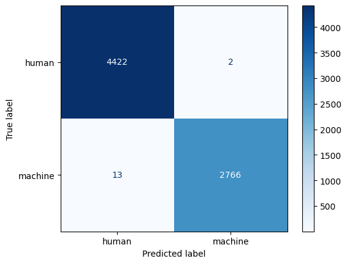

```python
from sklearn.metrics import confusion_matrix, ConfusionMatrixDisplay
import matplotlib.pyplot as plt

cm = confusion_matrix(tokenized_test_ds['label'], processed_predictions)

labels = ['human', 'machine']
disp = ConfusionMatrixDisplay(confusion_matrix=cm, display_labels=labels)
disp.plot(cmap=plt.cm.Blues)
plt.show()
```

```python
file_name = f"{project_name}-v12.ipynb"
html_file_name = f"{file_name.replace('.ipynb', '.html')}"

command = f"jupyter nbconvert '{file_name}' --to html --output-dir './html' --output '{html_file_name}'"
get_ipython().system(command)
```

[output not shown]